# Red Wine Exploratory Data Analysis by Cagri Aslanbas

This report explores a dataset containing attributes for approximately 1600 red wines. This dataset also includes the ratings between 0 (very bad) to 10 (very excellent), which were rated by at least 3 wine experts.

# Univariate Plots Section

```
## [1] 1599   13
```

```
##  [1] "X"                    "fixed.acidity"        "volatile.acidity"
##  [4] "citric.acid"          "residual.sugar"       "chlorides"
##  [7] "free.sulfur.dioxide"  "total.sulfur.dioxide" "density"
## [10] "pH"                   "sulphates"            "alcohol"
## [13] "quality"
```

```
## 'data.frame':    1599 obs. of  13 variables:
##  $ X                   : int  1 2 3 4 5 6 7 8 9 10 ...
##  $ fixed.acidity       : num  7.4 7.8 7.8 11.2 7.4 7.4 7.9 7.3 7.8 7.5 ...
##  $ volatile.acidity    : num  0.7 0.88 0.76 0.28 0.7 0.66 0.6 0.65 0.58 0.5 ...
##  $ citric.acid         : num  0 0 0.04 0.56 0 0 0.06 0 0.02 0.36 ...
##  $ residual.sugar      : num  1.9 2.6 2.3 1.9 1.9 1.8 1.6 1.2 2 6.1 ...
##  $ chlorides           : num  0.076 0.098 0.092 0.075 0.076 0.075 0.069 0.065 0.073 0.071 ...
##  $ free.sulfur.dioxide : num  11 25 15 17 11 13 15 15 9 17 ...
##  $ total.sulfur.dioxide: num  34 67 54 60 34 40 59 21 18 102 ...
##  $ density             : num  0.998 0.997 0.997 0.998 0.998 ...
##  $ pH                  : num  3.51 3.2 3.26 3.16 3.51 3.51 3.3 3.39 3.36 3.35 ...
##  $ sulphates           : num  0.56 0.68 0.65 0.58 0.56 0.56 0.46 0.47 0.57 0.8 ...
##  $ alcohol             : num  9.4 9.8 9.8 9.8 9.4 9.4 9.4 10 9.5 10.5 ...
##  $ quality             : int  5 5 5 6 5 5 5 7 7 5 ...
```

```
##        X          fixed.acidity   volatile.acidity  citric.acid
##  Min.   :   1.0   Min.   : 4.60   Min.   :0.1200   Min.   :0.000
##  1st Qu.: 400.5   1st Qu.: 7.10   1st Qu.:0.3900   1st Qu.:0.090
##  Median : 800.0   Median : 7.90   Median :0.5200   Median :0.260
##  Mean   : 800.0   Mean   : 8.32   Mean   :0.5278   Mean   :0.271
##  3rd Qu.:1199.5   3rd Qu.: 9.20   3rd Qu.:0.6400   3rd Qu.:0.420
##  Max.   :1599.0   Max.   :15.90   Max.   :1.5800   Max.   :1.000
##  residual.sugar     chlorides       free.sulfur.dioxide
##  Min.   : 0.900   Min.   :0.01200   Min.   : 1.00
##  1st Qu.: 1.900   1st Qu.:0.07000   1st Qu.: 7.00
##  Median : 2.200   Median :0.07900   Median :14.00
##  Mean   : 2.539   Mean   :0.08747   Mean   :15.87
##  3rd Qu.: 2.600   3rd Qu.:0.09000   3rd Qu.:21.00
##  Max.   :15.500   Max.   :0.61100   Max.   :72.00
##  total.sulfur.dioxide    density             pH          sulphates
##  Min.   :  6.00       Min.   :0.9901   Min.   :2.740   Min.   :0.3300
##  1st Qu.: 22.00       1st Qu.:0.9956   1st Qu.:3.210   1st Qu.:0.5500
##  Median : 38.00       Median :0.9968   Median :3.310   Median :0.6200
##  Mean   : 46.47       Mean   :0.9967   Mean   :3.311   Mean   :0.6581
##  3rd Qu.: 62.00       3rd Qu.:0.9978   3rd Qu.:3.400   3rd Qu.:0.7300
##  Max.   :289.00       Max.   :1.0037   Max.   :4.010   Max.   :2.0000
##     alcohol         quality
##  Min.   : 8.40   Min.   :3.000
##  1st Qu.: 9.50   1st Qu.:5.000
##  Median :10.20   Median :6.000
##  Mean   :10.42   Mean   :5.636
##  3rd Qu.:11.10   3rd Qu.:6.000
##  Max.   :14.90   Max.   :8.000
```

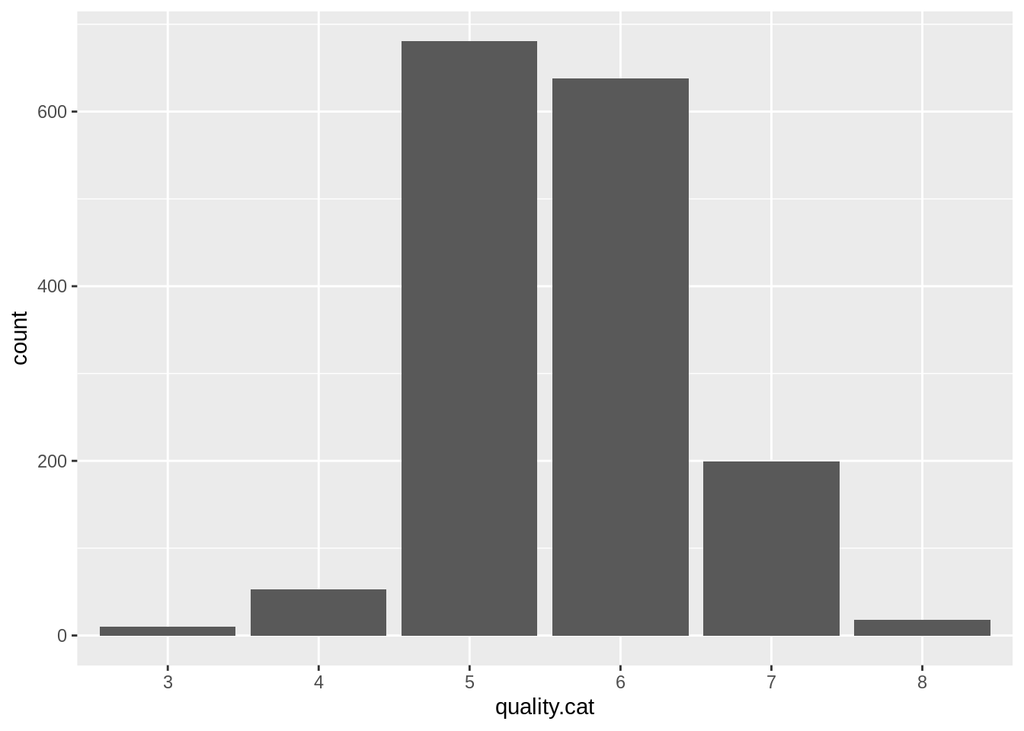

```
##
##   3   4   5   6   7   8
##  10  53 681 638 199  18
```

```
##    Min. 1st Qu.  Median    Mean 3rd Qu.    Max.
##   3.000   5.000   6.000   5.636   6.000   8.000
```

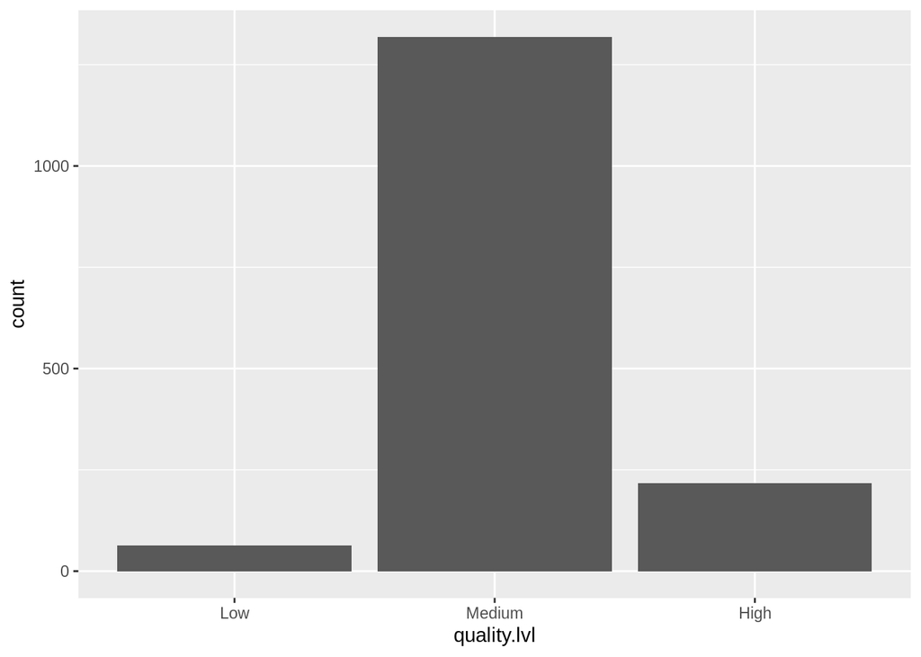

```
##
##    Low Medium   High
##     63   1319    217
```

We can say that most of the red wines have quality rating of 5 and 6, which is followed by 7. This result is also visible in the quality.lvl histogram, where the count of the medium quality red wines are more than 1000.

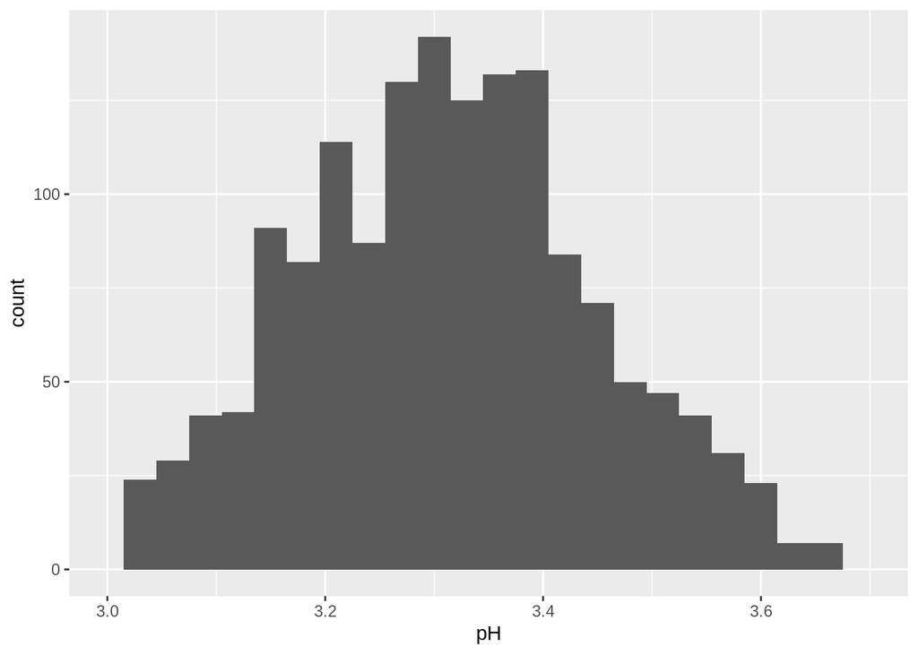

```
##    Min. 1st Qu.  Median    Mean 3rd Qu.    Max.
##   2.740   3.210   3.310   3.311   3.400   4.010
```

When we check out the histogram for the pH values of red wines, we can say that it is has a normal distribution. The pH value is peaking up around 3.35, most of them residing between 3.0 and 3.7. Therefore I trimmed the lowest and highest pH values and limited the pH values between 3.0 and 3.7.

Let’s take a look at the histograms of fixed and volatile acidities and citric acid.

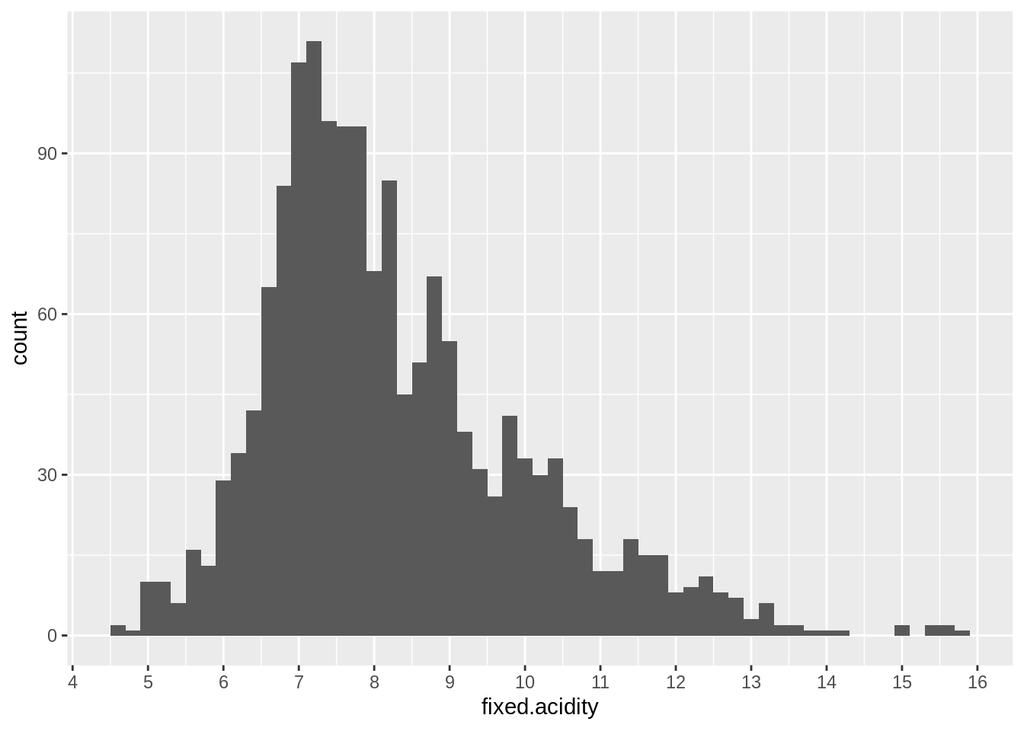

```
##    Min. 1st Qu.  Median    Mean 3rd Qu.    Max.
##    4.60    7.10    7.90    8.32    9.20   15.90
```

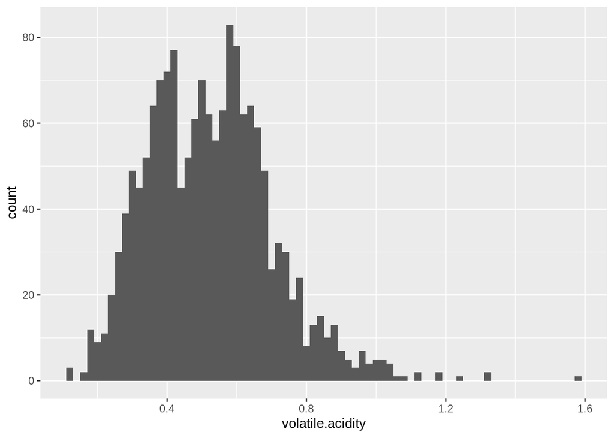

```
##    Min. 1st Qu.  Median    Mean 3rd Qu.    Max.
##  0.1200  0.3900  0.5200  0.5278  0.6400  1.5800
```

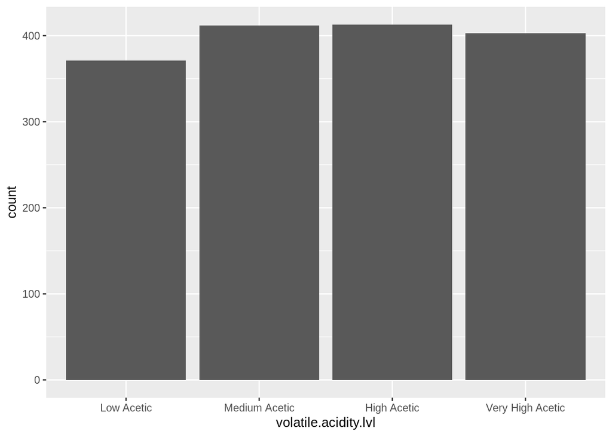

```
##
##       Low Acetic    Medium Acetic      High Acetic Very High Acetic
##              371              412              413              403
```

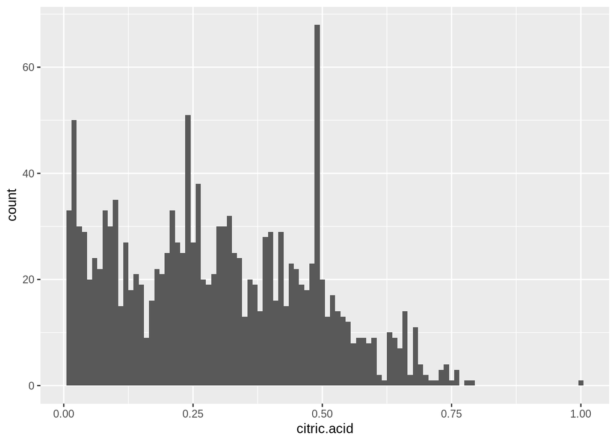

```
##    Min. 1st Qu.  Median    Mean 3rd Qu.    Max.
##   0.000   0.090   0.260   0.271   0.420   1.000
```

```
##
##    0 0.01 0.02 0.03 0.04 0.05 0.06 0.07 0.08 0.09  0.1 0.11 0.12 0.13 0.14
##  132   33   50   30   29   20   24   22   33   30   35   15   27   18   21
## 0.15 0.16 0.17 0.18 0.19  0.2 0.21 0.22 0.23 0.24 0.25 0.26 0.27 0.28 0.29
##   19    9   16   22   21   25   33   27   25   51   27   38   20   19   21
##  0.3 0.31 0.32 0.33 0.34 0.35 0.36 0.37 0.38 0.39  0.4 0.41 0.42 0.43 0.44
##   30   30   32   25   24   13   20   19   14   28   29   16   29   15   23
## 0.45 0.46 0.47 0.48 0.49  0.5 0.51 0.52 0.53 0.54 0.55 0.56 0.57 0.58 0.59
##   22   19   18   23   68   20   13   17   14   13   12    8    9    9    8
##  0.6 0.61 0.62 0.63 0.64 0.65 0.66 0.67 0.68 0.69  0.7 0.71 0.72 0.73 0.74
##    9    2    1   10    9    7   14    2   11    4    2    1    1    3    4
## 0.75 0.76 0.78 0.79    1
##    1    3    1    1    1
```

Fixed acidity histogram is quite right skewed, having a peak value around 7.0, where volatile acidity histogram is almost bimodal, having peak values around both 0.4 and 0.6.

I have also created a factored new variable called “volatile.acidity.lvl”, which consists of 4 categories: Low Acetic, Medium Acetic, High Acetic and Very High Acetic by using 1st, 2nd, 3rd and 4th quartiles.

Lastly, there were lots of wines with 0 citric acid. I have eliminated them and, we get a clear trimodal histogram for citric acid, which has peaks around 0.02, 0.24 and 0.49.

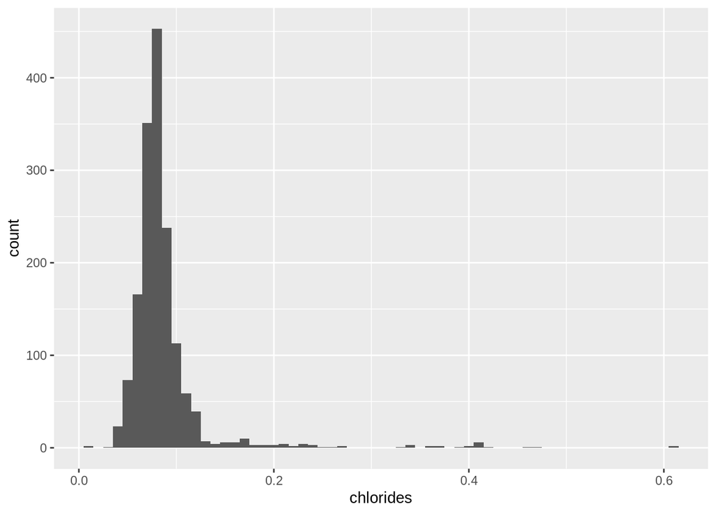

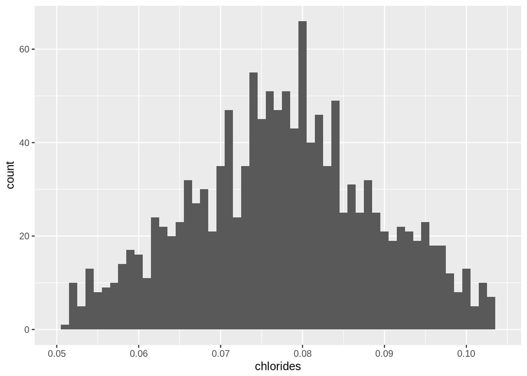

```
##    Min. 1st Qu.  Median    Mean 3rd Qu.    Max.
## 0.01200 0.07000 0.07900 0.08747 0.09000 0.61100
```

```
##
## 0.012 0.034 0.038 0.039 0.041 0.042 0.043 0.044 0.045 0.046 0.047 0.048
##     2     1     2     4     4     3     1     5     4     4     4     8
## 0.049  0.05 0.051 0.052 0.053 0.054 0.055 0.056 0.057 0.058 0.059  0.06
##     8    12     1    10     5    13     8     9    10    14    17    16
## 0.061 0.062 0.063 0.064 0.065 0.066 0.067 0.068 0.069  0.07 0.071 0.072
##    11    24    22    20    23    32    27    30    21    35    47    24
## 0.073 0.074 0.075 0.076 0.077 0.078 0.079  0.08 0.081 0.082 0.083 0.084
##    35    55    45    51    47    51    43    66    40    46    35    49
## 0.085 0.086 0.087 0.088 0.089  0.09 0.091 0.092 0.093 0.094 0.095 0.096
##    25    31    25    32    25    21    19    22    21    19    23    18
## 0.097 0.098 0.099   0.1 0.101 0.102 0.103 0.104 0.105 0.106 0.107 0.108
##    18    12     8    13     5    10     7    16     6     8     9     1
## 0.109  0.11 0.111 0.112 0.113 0.114 0.115 0.116 0.117 0.118 0.119  0.12
##     3     8     7     6     1    11     5     2     4     8     3     3
## 0.121 0.122 0.123 0.124 0.125 0.126 0.127 0.128 0.132 0.136 0.137 0.143
##     2     7     6     3     1     1     1     1     4     1     1     1
## 0.145 0.146 0.147 0.148 0.152 0.153 0.157 0.159 0.161 0.165 0.166 0.168
##     1     1     1     1     2     1     3     1     1     1     3     1
## 0.169  0.17 0.171 0.172 0.174 0.176 0.178 0.186  0.19 0.194   0.2 0.205
##     1     1     2     1     1     1     2     1     1     1     1     2
## 0.213 0.214 0.216 0.222 0.226  0.23 0.235 0.236 0.241 0.243  0.25 0.263
##     1     3     1     1     2     1     1     1     1     1     1     1
## 0.267  0.27 0.332 0.337 0.341 0.343 0.358  0.36 0.368 0.369 0.387 0.401
##     1     1     1     1     1     1     1     1     1     1     1     1
## 0.403 0.413 0.414 0.415 0.422 0.464 0.467  0.61 0.611
##     1     1     2     3     1     1     1     1     1
```

Most of the chloride (the amount of salt) amount per wine resides between 0.05 and 0.1 so I trimmed the histogram with chlorides between 0.05 and 0.104 grams/liter and got a normal distribution.

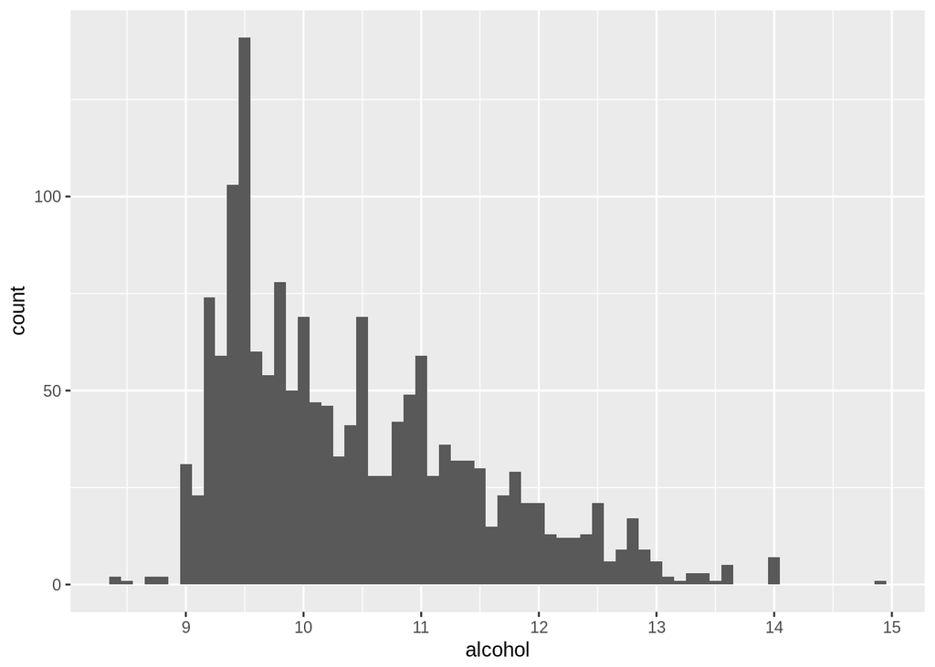

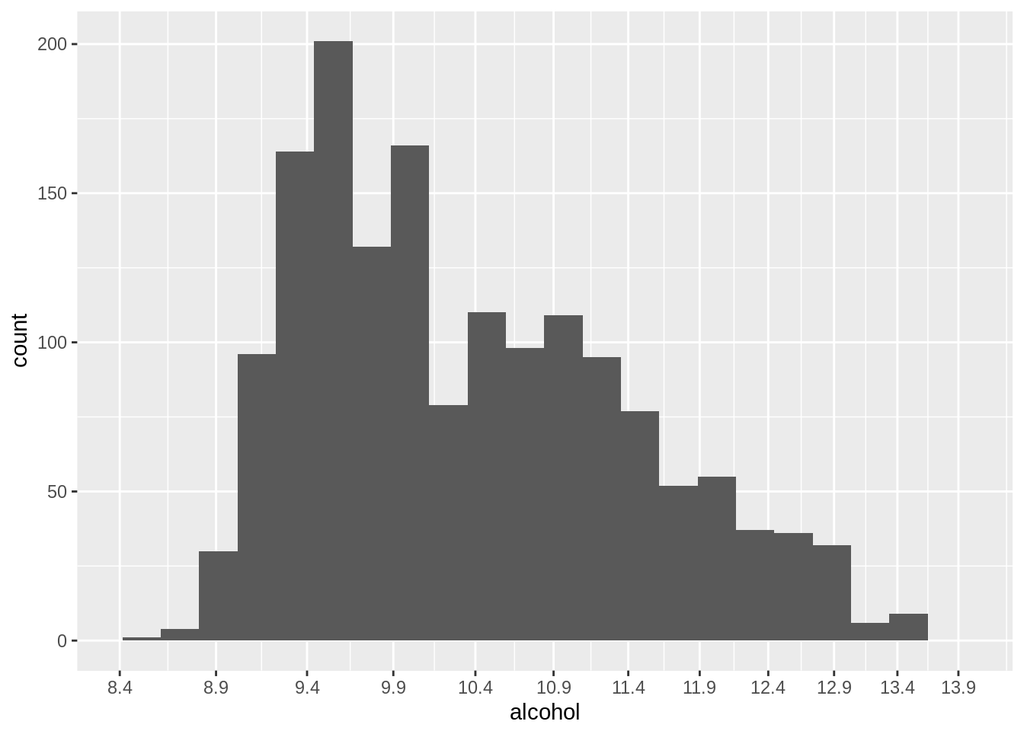

```
##    Min. 1st Qu.  Median    Mean 3rd Qu.    Max.
##    8.40    9.50   10.20   10.42   11.10   14.90
```

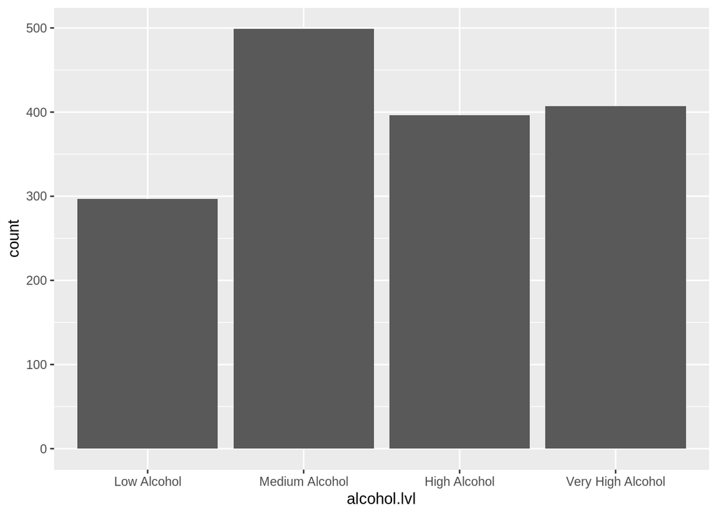

```
##
##       Low Alcohol    Medium Alcohol      High Alcohol Very High Alcohol
##               297               499               396               407
```

We have a right skewed tailed histogram for the alcohol histogram for red wines. The mean alcohol percentage is 10.42 and the median is 10.20. When we transform the alcohol with logaritmic (log10) scale and get rid of the outlier wine with 14.9 percent alcohol, we got a more friendly histogram, which is less tailed. The alcohol percent peaks around 9.4 and 9.5.

For further analysis, I have added a factored new variable called “alcohol.lvl”, which consists of 4 categories: Low Alcohol, Medium Alcohol, High Alcohol and Very High Alcohol by using 1st, 2nd, 3rd and 4th quartiles.

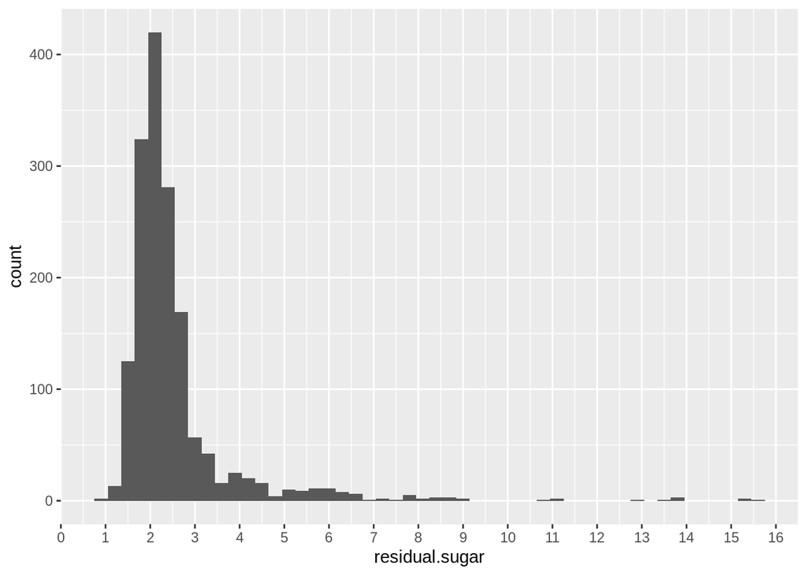

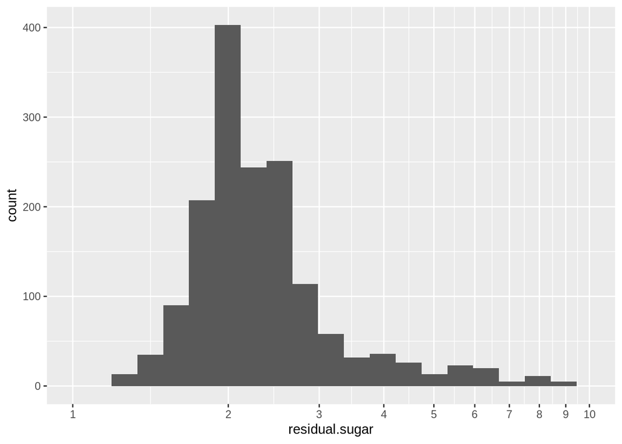

```
##    Min. 1st Qu.  Median    Mean 3rd Qu.    Max.
##   0.900   1.900   2.200   2.539   2.600  15.500
```

```
##
##  0.9  1.2  1.3  1.4  1.5  1.6 1.65  1.7 1.75  1.8  1.9    2 2.05  2.1 2.15
##    2    8    5   35   30   58    2   76    2  129  117  156    2  128    2
##  2.2 2.25  2.3 2.35  2.4  2.5 2.55  2.6 2.65  2.7  2.8 2.85  2.9 2.95    3
##  131    1  109    1   86   84    1   79    1   39   49    1   24    1   25
##  3.1  3.2  3.3  3.4 3.45  3.5  3.6 3.65  3.7 3.75  3.8  3.9    4  4.1  4.2
##    7   15   11   15    1    2    8    1    4    1    8    6   11    6    5
## 4.25  4.3  4.4  4.5  4.6 4.65  4.7  4.8    5  5.1 5.15  5.2  5.4  5.5  5.6
##    1    8    4    4    6    2    1    3    1    5    1    3    1    8    6
##  5.7  5.8  5.9    6  6.1  6.2  6.3  6.4 6.55  6.6  6.7    7  7.2  7.3  7.5
##    1    4    3    4    4    3    2    3    2    2    2    1    1    1    1
##  7.8  7.9  8.1  8.3  8.6  8.8  8.9    9 10.7   11 12.9 13.4 13.8 13.9 15.4
##    2    3    2    3    1    2    1    1    1    2    1    1    2    1    2
## 15.5
##    1
```

The shape for the residual sugar histogram is similar to that of alcohol, which is right skewed. After applying log10 scale, it turned into a more normal distributed shape.

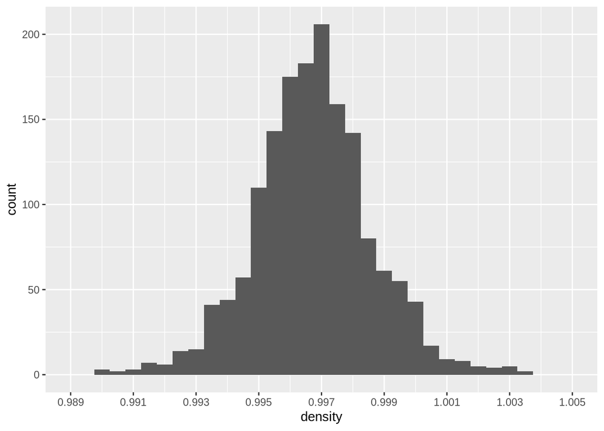

```
##    Min. 1st Qu.  Median    Mean 3rd Qu.    Max.
##  0.9901  0.9956  0.9968  0.9967  0.9978  1.0037
```

The density histogram is a perfect example for the normal distribution, varying between 0.9901 and 1.0037 and having a peak around 0.997. The mean density is 0.9967 g/cm3 and median is 0.9968 g/cm3 which are almost the same.

In the attributes description, it is noted that the density is close to that of water, which is 1 grams/liter, depending on alcohol percentage and sugar content. This made me wonder about these relationships and the correlation between the density-alcohol and density-sugar for red wines.

# Univariate Analysis

### What is the structure of your dataset?

There are 1599 red wine observations with 11 input variables (fixed acidity, volatile acidity, citric acid, residual sugar, chlorides, free sulfur dioxide, total sulfur dioxide, density, pH, sulphates, alcohol and an output variable quality rating.

None of these variables are factored. Only quality variable (score from 0 (worst) to 10 (best)) is categorical, others are all continuous with numeric values.

Some other observations:

- Median alcohol percentage is 10.20 and the maximum is 14.90
- Most of the red wines have quality ratings of 5 or 6. There are no red wines with quality ratings 0, 1, 2, 9 and 10
- Mean density is 0.9967 and median is 0.9968
- Volatile acidity difference between minimum and 3rd quartile is 0.52, while that between 3rd quartile and maximum is 0.94
- The mean salt (chloride) in red wines is 0.08747 grams/liter

### What is/are the main feature(s) of interest in your dataset?

My main features of interest will be density, it’s correlation with alcohol and sugar content. There might be a model to predict the quality of a red wine by looking at these.

### What other features in the dataset do you think will help support your investigation into your feature(s) of interest?

I think there might also be some correlation between the acetic acid (volatile acidity), citric acid and quality of red wines.

### Did you create any new variables from existing variables in the dataset?

I have created two new variables. First, “quality.lvl” which consists of three factored groups: “low”, “medium”, “high”. Quality ratings equeal or less than 4 belongs to “low” quality, qualities 5 and 6 belongs to “medium” and quality ratings equal or more than 7 is grouped into “high”. Second, “quality.cat”, which is the factored version of the “quality” column (having same values).

I have also created a factored new variable called “volatile.acidity.lvl”, which consists of 4 categories: Low Acetic, Medium Acetic, High Acetic and Very High Acetic by using 1st, 2nd, 3rd and 4th quartiles.

Finally, I have also added a factored new variable called “alcohol.lvl”, which consists of 4 categories: Low Alcohol, Medium Alcohol, High Alcohol and Very High Alcohol by using 1st, 2nd, 3rd and 4th quartiles.

of the data? If so, why did you do this?

# Bivariate Plots Section

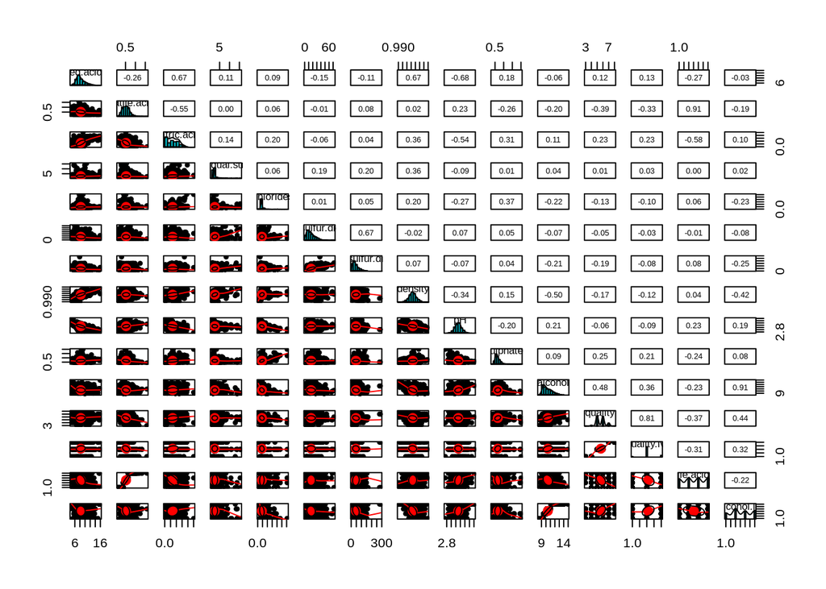

Taking a closer look at the scatterplot matrix, it’s clear that there is a negative correlation between volatile acidity (acetic acid) and red wine quality. The citric acid has a reatively weak but a positive correlation with red wine quality. Lets scrutinize those separate bivariate plots.

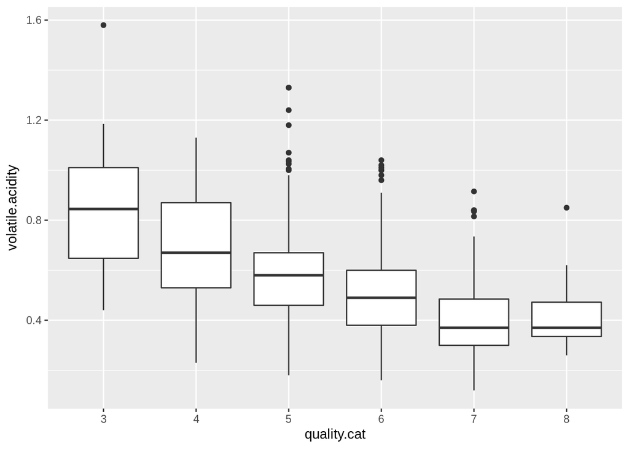

```
##
##  Pearson's product-moment correlation
##
## data:  quality and volatile.acidity
## t = -16.954, df = 1597, p-value < 2.2e-16
## alternative hypothesis: true correlation is not equal to 0
## 95 percent confidence interval:
##  -0.4313210 -0.3482032
## sample estimates:
##        cor
## -0.3905578
```

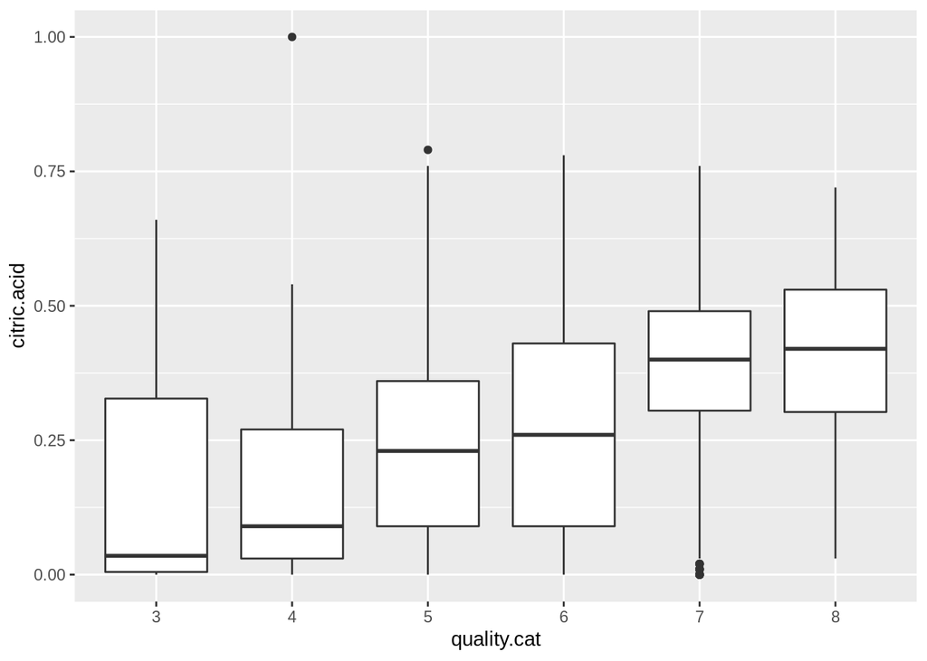

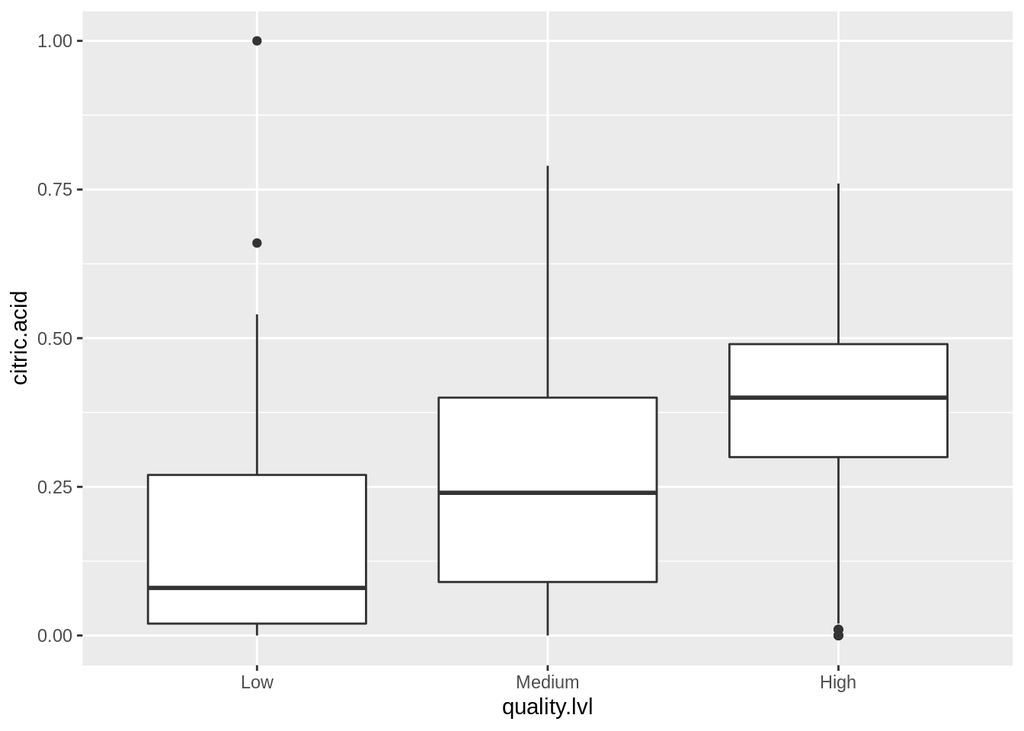

```
##
##  Pearson's product-moment correlation
##
## data:  quality and citric.acid
## t = 9.2875, df = 1597, p-value < 2.2e-16
## alternative hypothesis: true correlation is not equal to 0
## 95 percent confidence interval:
##  0.1793415 0.2723711
## sample estimates:
##       cor
## 0.2263725
```

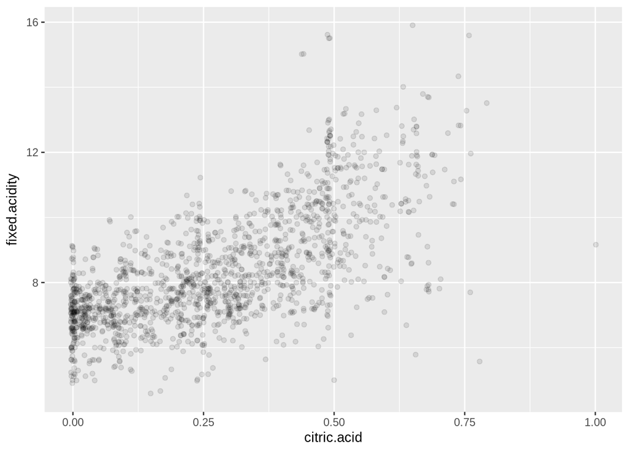

```
##
##  Pearson's product-moment correlation
##
## data:  citric.acid and fixed.acidity
## t = 36.234, df = 1597, p-value < 2.2e-16
## alternative hypothesis: true correlation is not equal to 0
## 95 percent confidence interval:
##  0.6438839 0.6977493
## sample estimates:
##       cor
## 0.6717034
```

As volatile acidity (amount of acetic acid) increases, the quality of red wines decreases. A correlation coefficient around -0.39 also tells that there is a meaningful negative correlation between those two.

On the other hand, the correlation coefficient of 0.23 is not really helpful to say that citric acid and red wine quality have a positive correlation. Moreover, the boxplot between those two variables also does not say too much. But when citric acid and quality level relationship is box plotted, there seems a little bit stronger correlation.

As can be seen on the third scatterplot, fixed acidity (tartaic acid) and citric acid have a very strong positive correlation which is very important (r=0.67)

[output not shown]

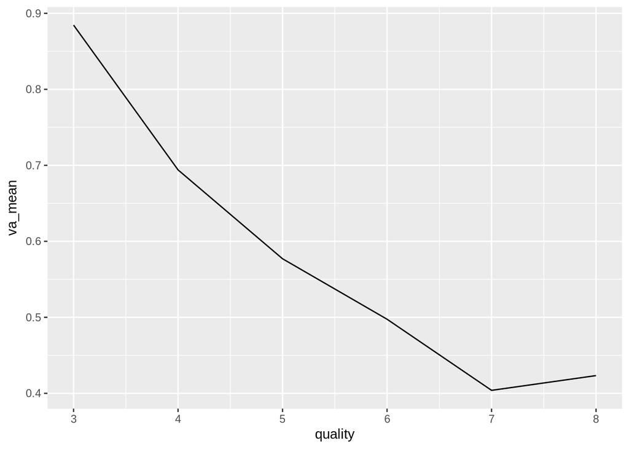

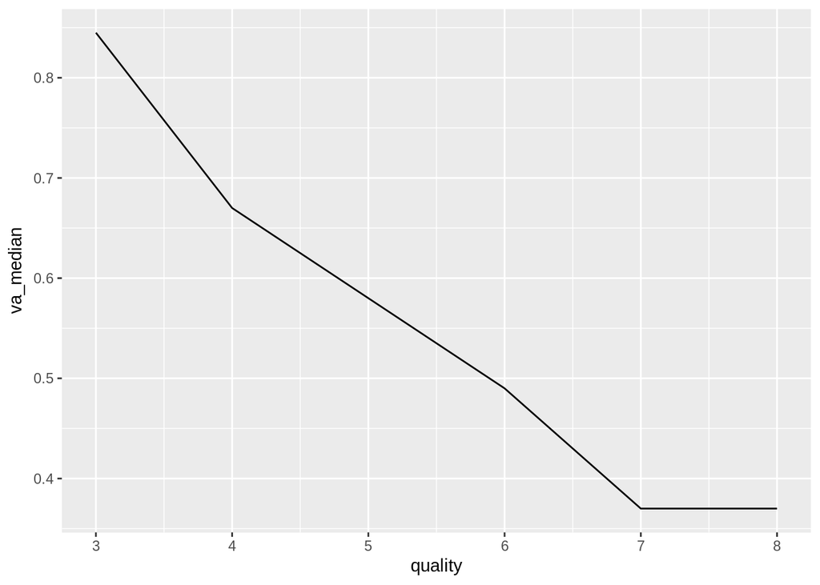

```
## df$quality: 3
##    Min. 1st Qu.  Median    Mean 3rd Qu.    Max.
##  0.4400  0.6475  0.8450  0.8845  1.0100  1.5800
## --------------------------------------------------------
## df$quality: 4
##    Min. 1st Qu.  Median    Mean 3rd Qu.    Max.
##   0.230   0.530   0.670   0.694   0.870   1.130
## --------------------------------------------------------
## df$quality: 5
##    Min. 1st Qu.  Median    Mean 3rd Qu.    Max.
##   0.180   0.460   0.580   0.577   0.670   1.330
## --------------------------------------------------------
## df$quality: 6
##    Min. 1st Qu.  Median    Mean 3rd Qu.    Max.
##  0.1600  0.3800  0.4900  0.4975  0.6000  1.0400
## --------------------------------------------------------
## df$quality: 7
##    Min. 1st Qu.  Median    Mean 3rd Qu.    Max.
##  0.1200  0.3000  0.3700  0.4039  0.4850  0.9150
## --------------------------------------------------------
## df$quality: 8
##    Min. 1st Qu.  Median    Mean 3rd Qu.    Max.
##  0.2600  0.3350  0.3700  0.4233  0.4725  0.8500
```

I have grouped red wines by their quality ratings (available from 3 to 8 in data frame). I have also calculated each groups volatile acidity mean and median by using summarise function of dplyr package. By looking at both quality groups - volatile acidity mean and quality groups - voladity acidity median per group line graphs, it is highly observable that when volatile acidity (acetic acid) increases, quality of red wine decreases. The reason for that might be; a wine with a tangible amount of acid taste is perceived as low quality, as its taste of flavor is not recognizable.

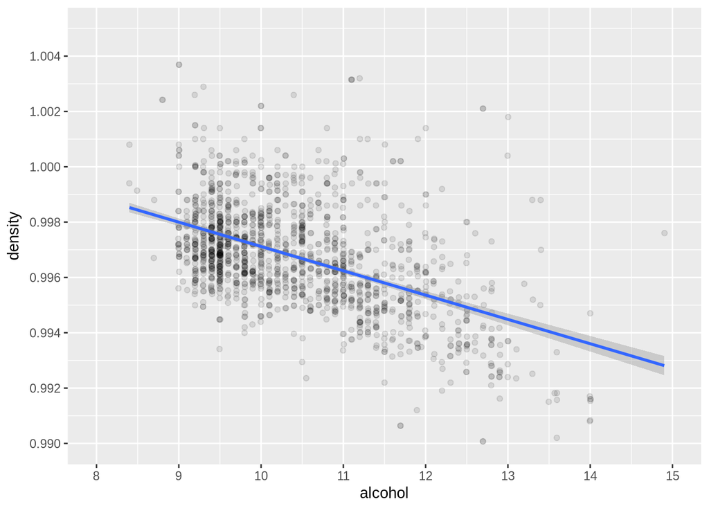

```
##
##  Pearson's product-moment correlation
##
## data:  alcohol and density
## t = -22.838, df = 1597, p-value < 2.2e-16
## alternative hypothesis: true correlation is not equal to 0
## 95 percent confidence interval:
##  -0.5322547 -0.4583061
## sample estimates:
##        cor
## -0.4961798
```

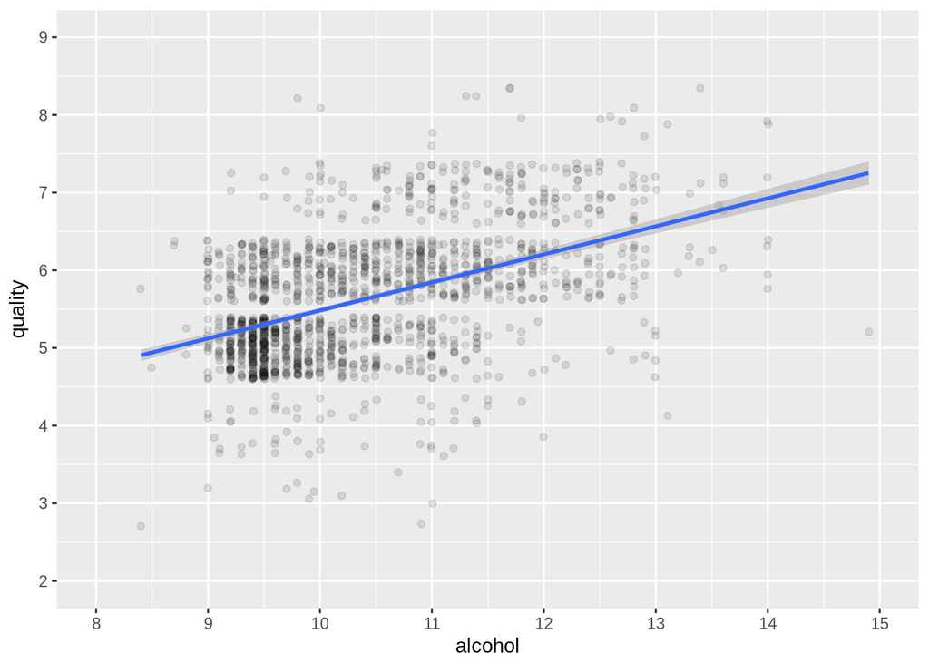

```
##
##  Pearson's product-moment correlation
##
## data:  alcohol and quality
## t = 21.639, df = 1597, p-value < 2.2e-16
## alternative hypothesis: true correlation is not equal to 0
## 95 percent confidence interval:
##  0.4373540 0.5132081
## sample estimates:
##       cor
## 0.4761663
```

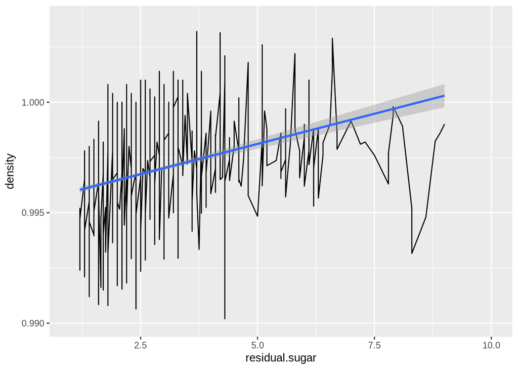

```
##
##  Pearson's product-moment correlation
##
## data:  residual.sugar and density
## t = 15.189, df = 1597, p-value < 2.2e-16
## alternative hypothesis: true correlation is not equal to 0
## 95 percent confidence interval:
##  0.3116908 0.3973835
## sample estimates:
##       cor
## 0.3552834
```

As can be clearly seen in the scatterplot, alcohol and density have a strong negative correlation with a correlation coefficient of -0.50. As density of alcohol is lower than pure water, the increase of alcohol in red wine decreases its density.

There is also a strong positive relationship (correlation coefficient = 0.48) between alcohol and red wine quality.

After eliminating the sugar outliers and draw the line graph between sugar content and density of red wines, we see that there is a positive, relatively weak correlation, which is 0.36. It seems like alcohol content is more effective in red wine density when compared to sugar content.

# Bivariate Analysis

### Talk about some of the relationships you observed in this part of the investigation. How did the feature(s) of interest vary with other features in the dataset?

- Alcohol percentage is strongly negative related to density of red wine as alcohol’s density is lower than pure water. On contrast, increasing alcohol amount in red wines strongly raises its quality.
- By having a strong negative correlation with its quality, volatile acidity is one of the most important factors that decrease the quality of red wines.

### Did you observe any interesting relationships between the other features (not the main feature(s) of interest)?

Yes. Probably because of chemical reasons, the amount of fixed acidity (tartaic acid) is strongly positive correlated (r=0.67) with the amount of citric acid in red wines.

# Multivariate Plots Section

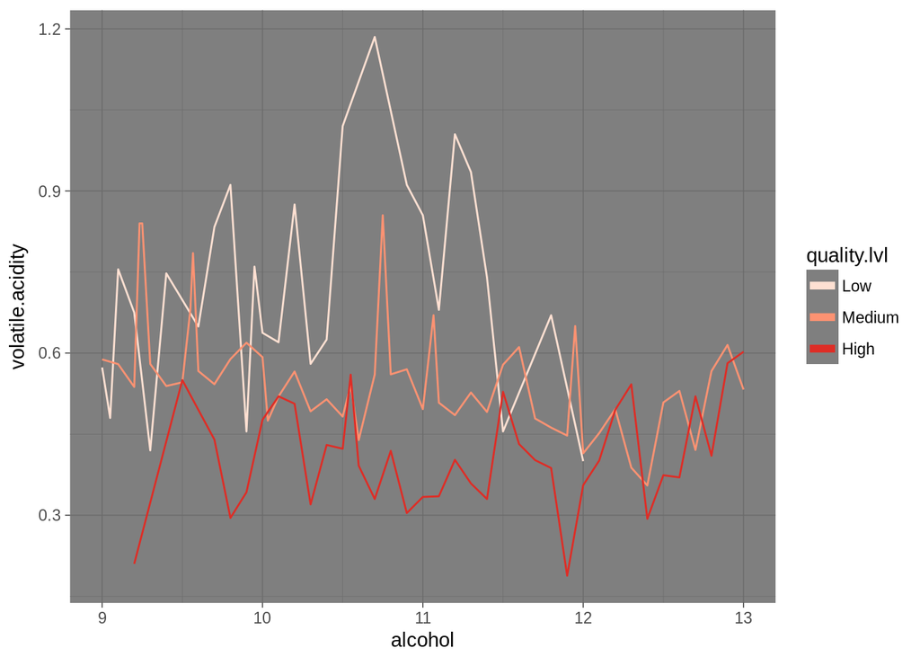

The volatile acidity of low quality red wines makes its peak with 1.2 g/lt, with around 10.6% alcohol percentage. Medium quality wines have their volatile acidity peak around 0.85 g/lt with alcohol percentages around 10.6% and 9.25%. Maximum volatile acidity of high quality wines is around 0.6 g/lt, which is observed at 13% alcohol.

[output not shown]

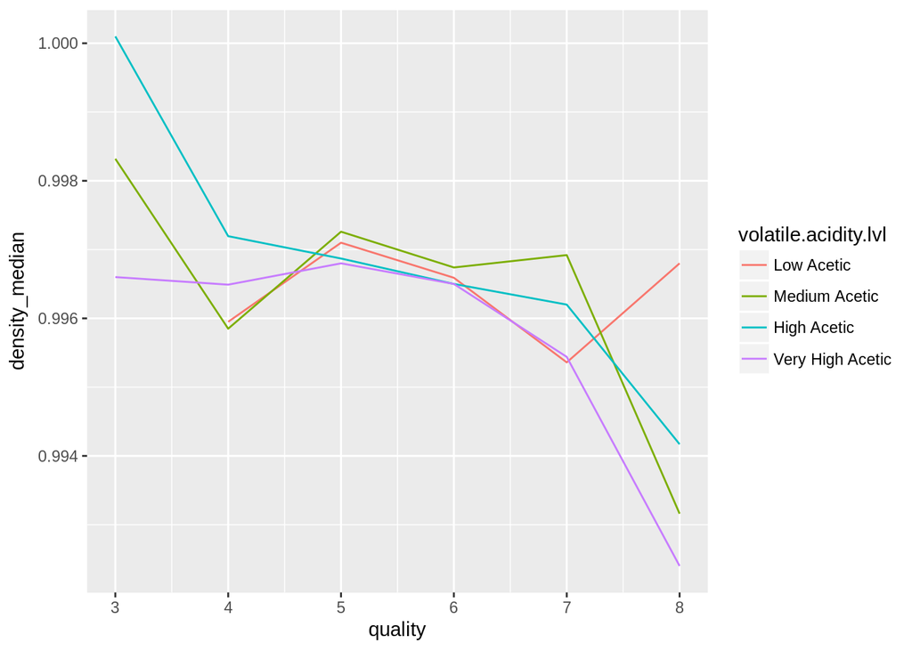

For red wines with low acetic acid (volatile acidity), high quality red wines are associated with a density around 0.997. For other acetic acidity levels, lower densities between 0.992 and 0.994 is a must for being high quality. There might be a good model from here.

[output not shown]

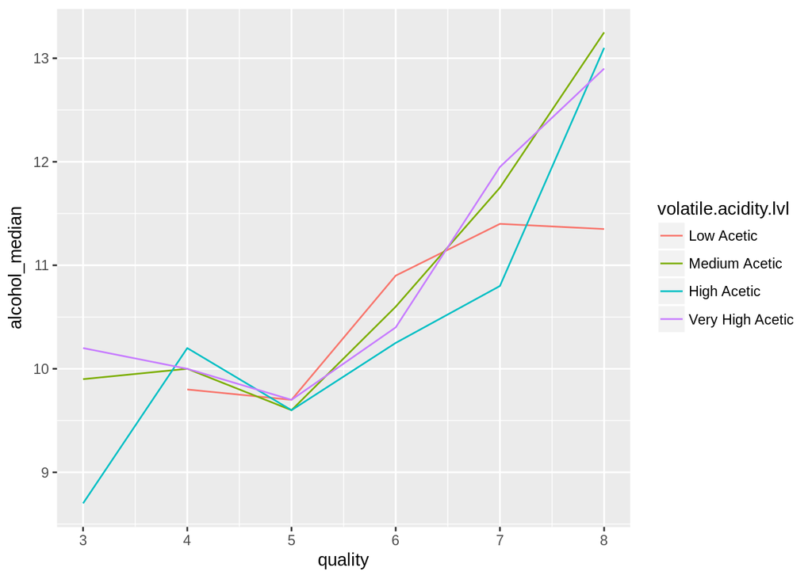

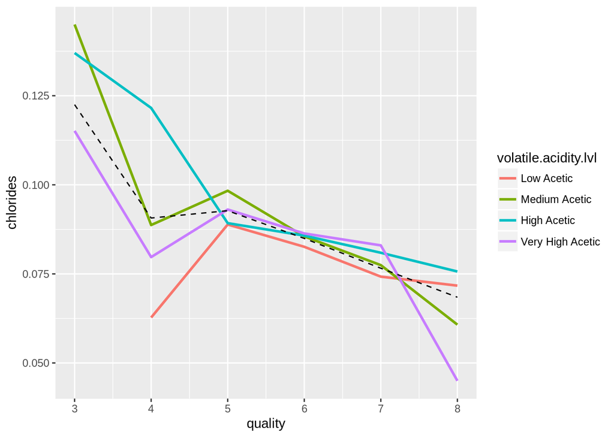

The behavior of medium, high and very high volatile acidities tend similar in terms of alcohol vs. quality.

Red wines belonging to low volatile acidity group tends to have a narrower variety of alcohol percentage, from 9.8% to 11.4%, where other levels have a wider varieties between 9% and 13%. There also might be a good model out of this relationship.

Similarly, except low acetic wines, chlorides amount has negative effect on quality for all volatile acidity levels. We can create another model from this data as well.

```
##
## Calls:
## m1: lm(formula = quality ~ volatile.acidity, data = df)
## m2: lm(formula = quality ~ volatile.acidity + chlorides, data = df)
##
## ================================================
##                          m1            m2
## ------------------------------------------------
##   (Intercept)           6.566***      6.708***
##                        (0.058)       (0.065)
##   volatile.acidity     -1.761***     -1.732***
##                        (0.104)       (0.103)
##   chlorides                          -1.808***
##                                      (0.394)
## ------------------------------------------------
##   R-squared             0.153         0.164
##   adj. R-squared        0.152         0.163
##   sigma                 0.744         0.739
##   F                   287.444       156.083
##   p                     0.000         0.000
##   Log-likelihood    -1794.312     -1783.810
##   Deviance            883.198       871.672
##   AIC                3594.624      3575.620
##   BIC                3610.756      3597.128
##   N                  1599          1599
## ================================================
```

```
##
## Calls:
## m1: lm(formula = quality ~ volatile.acidity, data = df)
## m2: lm(formula = quality ~ volatile.acidity + chlorides, data = df)
## m3: lm(formula = quality ~ volatile.acidity + chlorides + alcohol,
##     data = df)
##
## ==============================================================
##                          m1            m2            m3
## --------------------------------------------------------------
##   (Intercept)           6.566***      6.708***      3.157***
##                        (0.058)       (0.065)       (0.196)
##   volatile.acidity     -1.761***     -1.732***     -1.382***
##                        (0.104)       (0.103)       (0.095)
##   chlorides                          -1.808***     -0.334
##                                      (0.394)       (0.364)
##   alcohol                                           0.311***
##                                                    (0.016)
## --------------------------------------------------------------
##   R-squared             0.153         0.164         0.317
##   adj. R-squared        0.152         0.163         0.316
##   sigma                 0.744         0.739         0.668
##   F                   287.444       156.083       247.176
##   p                     0.000         0.000         0.000
##   Log-likelihood    -1794.312     -1783.810     -1621.391
##   Deviance            883.198       871.672       711.420
##   AIC                3594.624      3575.620      3252.782
##   BIC                3610.756      3597.128      3279.668
##   N                  1599          1599          1599
## ==============================================================
```

```
##        fit      lwr     upr
## 1 5.269837 3.959024 6.58065
```

As observed above, volatile acidity, and chlorides have the same effect on red wine quality; as they increase, quality decreases. I wanted to create a linear model out of that, which gave an R-squared value around 0.164, which is very low and hence, is not enough to explain about red wine quality alone.

Then I also added alcohol variable into the model as a 3rd variable and observed that the R-squared value is almost doubled to 0.317, which gave a better result.

I have created a custom red wine sample with alcohol percentage 10.00%, volatile acidity of 0.7 and chlorides 0.078. Getting its quality prediction, my final linear model gave me the results indicating that the lower quality value would be around 3.96 and upper quality rating would be 6.58.

# Multivariate Analysis

### Talk about some of the relationships you observed in this part of the investigation. Were there features that strengthened each other in terms of looking at your feature(s) of interest?

Chlorides and density have similar negative relationships with red wine quality.

### Were there any interesting or surprising interactions between features?

Low acetic (red wines with weak volatile acidity) red wines show different behaviours than the rest of the red wines when it comes to chlorides and density. These two variables almost do not have any effect on the quality of low acetic wines, although they have a negative relationship on the quality of the rest.

### OPTIONAL: Did you create any models with your dataset? Discuss the strengths and limitations of your model.

I have created two models:

- First model includes the volatile acidity and chlorides variables on the quality of red wines, coming out with a 0.164 R-squared value.
- When alcohol is added to the equation, our second model gave an R-squared value of 0.317.

Both of these R-squared values are not high enough to help us make predictions about the red wine quality by using these 3 variable. However, our second model might be additive as its R-squared value is bigger than 0.3.

# Final Plots and Summary

### Plot One

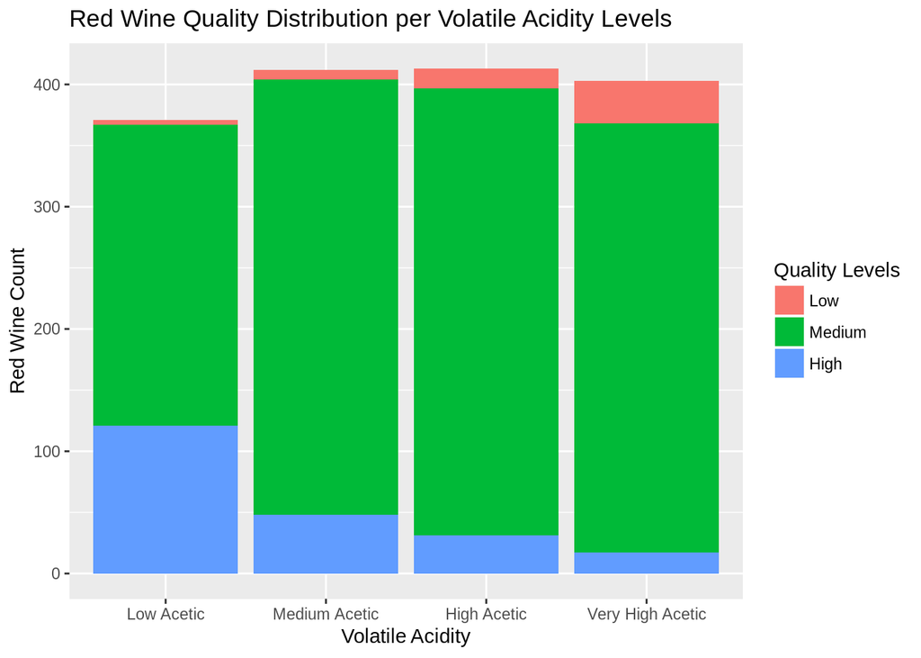

### Plot Two

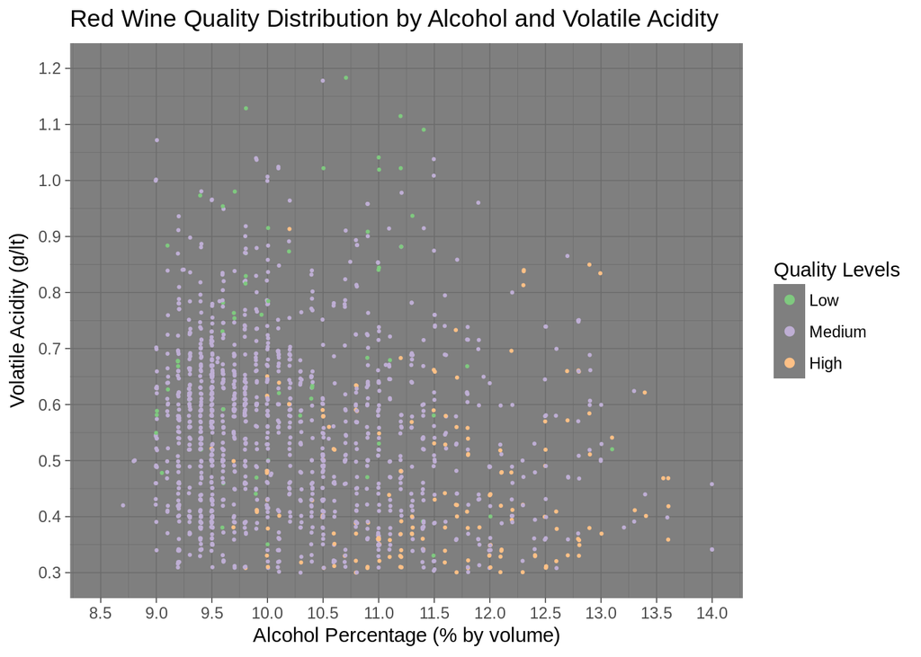

### Description Two

Low quality wines are intenser around the left upper area where volatile acidity is higher and alcohol is lower. Major amount of high quality wines, are placed around right lower part, where volatile acidity is lower and alcohol percent is higher.

### Plot Three

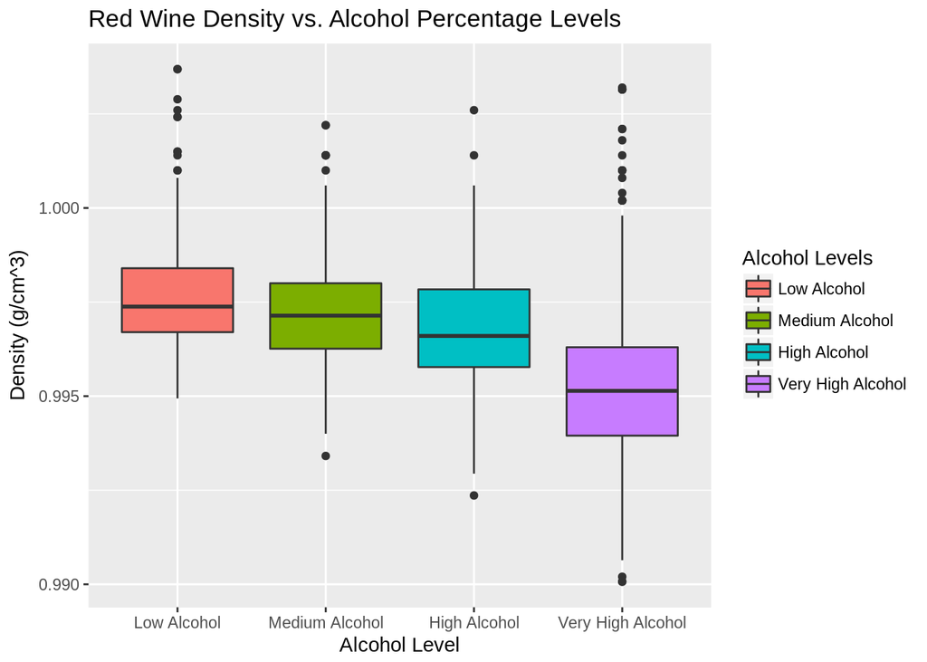

### Description Three

Median density tend to decrease when the amount of alcohol increases. The density variations for the middle %50 are similar accross different alcohol levels, changing between 0.0017 and 0.0023.

# Reflection

The red wine quality dataset contains information for 1599 red wines, created in 2009. I started by scrutinizing on individual variables in the data set, and then I explored interesting questions and leads as I continued to make observations on plots. Eventually, I explored the quality of red wines across many variables and created two progressive linear models to predict red wine qualities.

The notable observed strong relationships with red wine qualities were volatile acidity and alcohol percentage, while the first one is negative and the latter is positive. My first linear model was consisted of volatile acidity and chloride amount, having a 16.4% of the variance in the dataset. When I added the alcohol percentage in the equation and created my second linear model, I then had an increased 31.7% of the variance in the dataset.

The limitations of this data set was that there were very few observations, which panned out in scarce scatter plots. More over, there were no factored variables. Even though I created three factored variables corresponding to quality, alcohol and volatile acidity, it would be better if we had more in the original data. Lastly, having a variety from only 3 to 8, the quality ratings were not widely distributed, although the rating scale was between 0 and 10. I was wondering about how a recent red wine quality data might be seen as wine quality are said to be strongly related with their ages.